# Bioassay case study

Author

Andrew Gelman and Aki Vehtari

Published

2025-10-15

Modified

2026-08-20

This notebook includes the code for Bayesian Workflow book Section 3.5 *A simple example of probabilistic programming*.

# 1 Introduction

We demonstrate the role of statistical programming environments and probabilistic programming by going through the steps of data analysis and computation in the context of a simple example.

We work through an example by Racine-Poon et al. (1986), also included in Section 2.8 of *Bayesian Data Analysis (Gelman et al. 2013), of a logistic regression fit to a bioassay experiment.

**Load packages**

````r
library(rprojroot)
root <- has_file(".Bayesian-Workflow-root")$make_fix_file()
library(cmdstanr)
library(brms)
options(brms.backend = "cmdstanr", mc.cores = 4)
library(posterior)
library(ggplot2)
library(ggdist)
library(dplyr)
library(tidyr)
library(bayesplot)
theme_set(bayesplot::theme_default(base_family = "sans", base_size = 16))
library(marginaleffects)

print_stan_file <- function(file) {
  code <- readLines(file)
  if (isTRUE(getOption("knitr.in.progress")) &
        identical(knitr::opts_current$get("results"), "asis")) {
    # In render: emit as-is so Pandoc/Quarto does syntax highlighting
    block <- paste0("```stan", "\n", paste(code, collapse = "\n"), "\n", "```")
    knitr::asis_output(block)
  } else {
    writeLines(code)
  }
}
````

# 2 Bioassay data

Read the data from csv

```r
# df_bioassay <- read.csv("bioassay/data/bioassay.csv")
```

Data as data frame

```r
df_bioassay <- data.frame(
  dose = c(-0.86, -0.30, -0.05, 0.73),
  batch_size = c(5, 5, 5, 5),
  deaths = c(0, 1, 3, 5)
)
```

Data plotted with base R

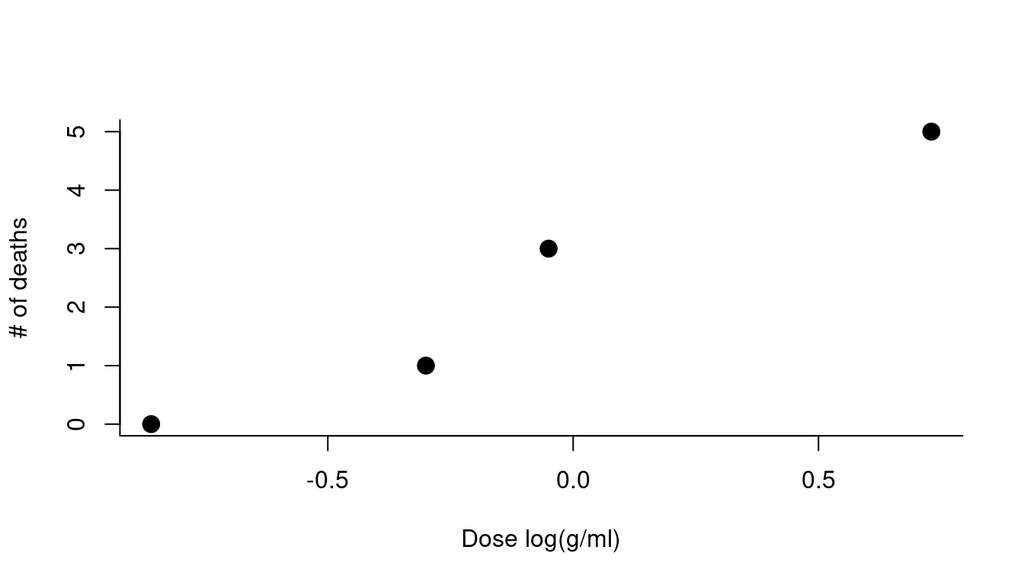

Figure 1

```r
with(df_bioassay,
     plot(dose, deaths, xlab = "Dose log(g/ml)", ylab = "# of deaths",
          pch = 19, cex = 1.5, bty = "l"))
```

Data plotted with ggplot

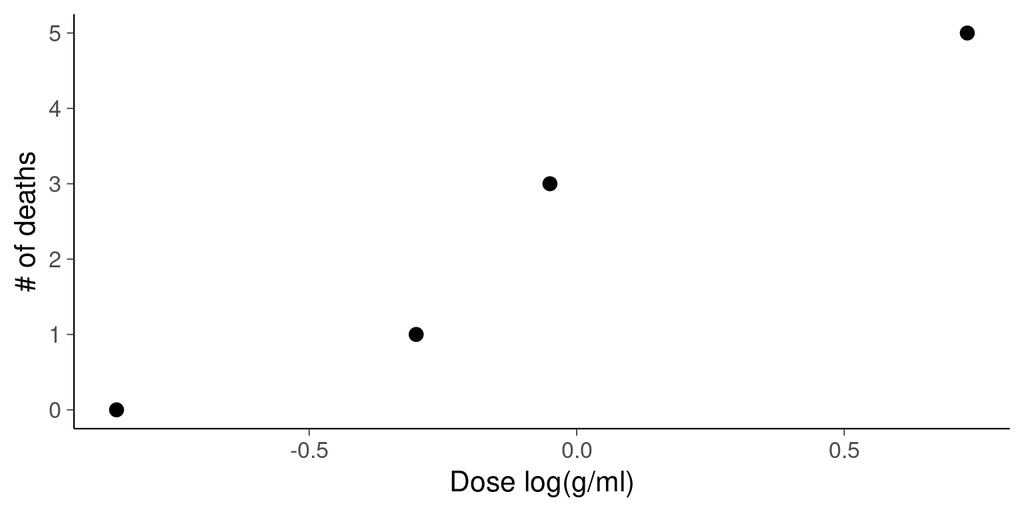

Figure 2

```r
df_bioassay |>
  ggplot(aes(x = dose, y = deaths)) +
  geom_point(size = 3) +
    labs(x = "Dose log(g/ml)", y = "# of deaths")
```

Data as list for CmdStanR

```r
bioassay_data <- with(df_bioassay,
                      list(J = nrow(df_bioassay),
                           x = dose,
                           N = batch_size,
                           y = deaths))
```

# 3 Stan models and inference

Stan model 0 (without priors)

```r
bioassay_stan_file <- root("bioassay","bioassay0.stan")
```

```r
print_stan_file(bioassay_stan_file)
```

```stan
data {
  int<lower=0> J;
  vector[J] x;
  array[J] int<lower=0> N;
  array[J] int<lower=0, upper=N> y;
}
parameters {
  real a;
  real b;
}
model {
  y ~ binomial_logit(N, a + b * x);
}
```

Compile the Stan model code using pedantic mode

```r
mod0 <- cmdstan_model(bioassay_stan_file, pedantic = TRUE)
```

Stan model 1 (with priors)

```r
bioassay_stan_file <- root("bioassay","bioassay1.stan")
```

```r
print_stan_file(bioassay_stan_file)
```

```stan
data {
  int<lower=0> J;
  vector[J] x;
  array[J] int<lower=0> N;
  array[J] int<lower=0, upper=N> y;
}
parameters {
  real a;
  real<lower=0> b;
}
model {
  {a, b} ~ normal(0, 5);
  y ~ binomial_logit(N, a + b * x);
}
```

Compile the updated Stan model code using pedantic mode

```r
mod1 <- cmdstan_model(bioassay_stan_file, pedantic = TRUE)
```

Sample with default settings (expect no progress output)

```r
fit1 <- mod1$sample(data = bioassay_data, refresh = 0)
```

# 4 Posterior summary

Posterior summary and MCMC diagnostics

```r
fit1
```

```
 variable  mean median   sd  mad    q5   q95 rhat ess_bulk ess_tail
     lp__ -5.91  -5.62 0.98 0.73 -7.82 -4.96 1.00     1790     2154
     a     0.58   0.55 0.78 0.78 -0.68  1.88 1.00     1971     2256
     b     6.39   6.10 2.50 2.53  2.79 10.87 1.00     1619     1591
```

Posterior draws as data frame

```r
draws1 <- fit1$draws(format="df")
```

Plot with base plot: data, 20 logistic curves given 20 posterior draws, and one logistic given the posterior mean

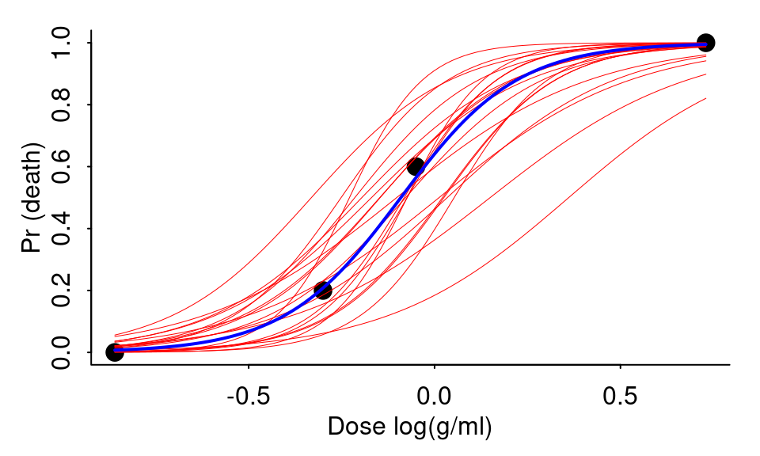

Figure 3

```r
par(mar=c(3,3,1,1), mgp=c(1.5,.5,0), tck=-.01)
with(df_bioassay,
     plot(dose, deaths/batch_size, xlab = "Dose log(g/ml)", ylab = "Pr (death)",
          pch=19, cex=1.5, bty="l"))
invlogit <- plogis
for (s in sample(nrow(draws1), 20)) {
  curve(invlogit(draws1$a[s] + draws1$b[s] * x),
        col = "red", lwd = 0.5, add = TRUE)
}
curve(invlogit(mean(draws1$a) + mean(draws1$b) * x),
      col = "blue", lwd = 2, add = TRUE)
```

Plot with ggplot: data, 20 logistic curves given 20 posterior draws, and one logistic given the posterior mean

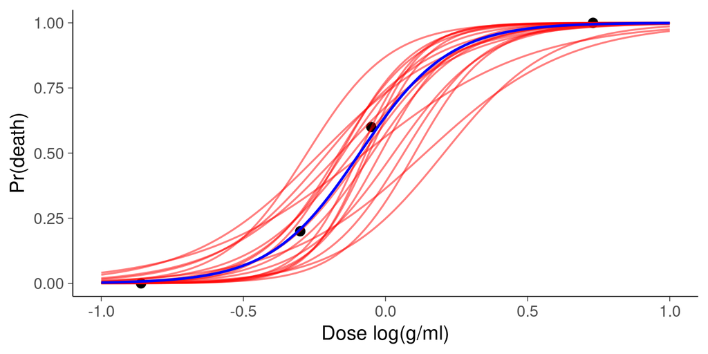

Figure 4

```r
draws1 |>
  resample_draws(ndraws = 20) |>
  expand_grid(x=seq(-1, 1, length = 100)) |>
  mutate(y = plogis(a + b * x)) |>
  ggplot() +
  geom_point(data = df_bioassay, aes(x = dose, y = deaths / batch_size), size = 3) +
  geom_line(aes(x = x, y = y, group = .draw), alpha = .5, color = "red") +
  geom_function(fun = \(x) plogis(mean(draws1$a) + mean(draws1$b)*x),
                color = "blue",
                linewidth = 1) +
  labs(x = "Dose log(g/ml)", y = "Pr(death)")
```

# 5 Derived quantities

Compute posterior draws for LD50 in log(g/ml) and in mg/ml

```r
draws1 <- draws1 |>
  mutate_variables(LD50_log_g_ml = -a / b,
                   LD50_mg_ml = 1000 * exp(LD50_log_g_ml))
```

Alternatively using base R (as posterior package draws object is more than just plain data frame, it is better to use `mutate_variables()`, which will also work for all other posterior draws objects (`draws_list`, `draws_array`, `draws_rvars`))

```r
draws1$LD50_log_g_ml <- -draws1$a /  draws1$b
draws1$LD50_mg_ml <- 1000 * exp(draws1$LD50_log_g_ml)
```

Summarise LD50 posterior

```r
draws1 |>
  subset_draws(variable = "LD50_log_g_ml") |>
  summarize_draws()
```

```
# A tibble: 1 × 10
  variable         mean  median    sd   mad     q5   q95  rhat ess_bulk ess_tail
  <chr>           <dbl>   <dbl> <dbl> <dbl>  <dbl> <dbl> <dbl>    <dbl>    <dbl>
1 LD50_log_g_ml -0.0809 -0.0916 0.135 0.113 -0.281 0.143  1.00    2683.    2587.
```

Common part for the next two LD50 plots (without data)

```r
ggplot_LD50_mg_ml <-
  ggplot(mapping = aes(x = LD50_mg_ml)) +
  scale_x_log10(limits = c(375,2700)) +
  labs(x = "LD50 mg/ml") +
  geom_vline(xintercept = c(500, 2000), alpha=0.1) +
  annotate(geom = "text", x = 500*0.96, y = .97, hjust = 1, label = "Category 3") +
  annotate(geom = "text", x = 1000, y = .97, label = "Category 4") +
  annotate(geom = "text", x = 2000*1.04, y = .97, hjust = 0, label = "Category 5") +
  theme_sub_axis_y(text = element_blank(),
                                        line = element_blank(),
                                        ticks = element_blank(),
                                        title = element_blank())
```

Quantile dot plot of the LD50 (mg/ml) posterior

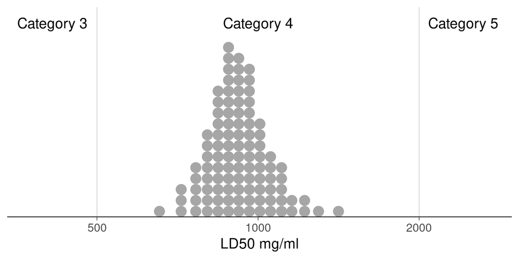

Figure 5

```r
ggplot_LD50_mg_ml +
  stat_dots(data = draws1, quantiles = 100) +
  coord_cartesian(expand = c(bottom = FALSE))
```

Kernel density plot of the LD50 (mg/ml) posterior

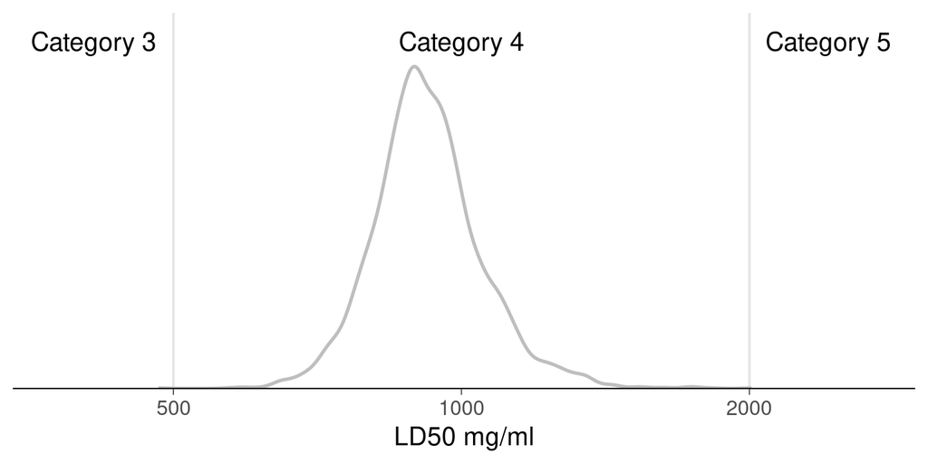

Figure 6

```r
ggplot_LD50_mg_ml +
  stat_slab(data = draws1, color = "gray", fill = NA) +
  coord_cartesian(expand = c(bottom = FALSE))
```

# 6 brms model and inference

The same model with `brms`

```r
bfit1 <- brm(deaths | trials(batch_size) ~ dose,
             family = binomial(),
             prior = c(prior(normal(0, 5), class = Intercept),
                       prior(normal(0, 5), lb = 0, class = b)),
             data = df_bioassay,
             refresh = 0)
```

Summary of the inference

```r
bfit1
```

```
 Family: binomial
  Links: mu = logit
Formula: deaths | trials(batch_size) ~ dose
   Data: df_bioassay (Number of observations: 4)
  Draws: 4 chains, each with iter = 2000; warmup = 1000; thin = 1;
         total post-warmup draws = 4000

Regression Coefficients:
          Estimate Est.Error l-95% CI u-95% CI Rhat Bulk_ESS Tail_ESS
Intercept     0.60      0.76    -0.79     2.15 1.00     2039     2144
dose          6.40      2.52     2.44    12.20 1.00     2655     1830

Draws were sampled using sample(hmc). For each parameter, Bulk_ESS
and Tail_ESS are effective sample size measures, and Rhat is the potential
scale reduction factor on split chains (at convergence, Rhat = 1).
```

Posterior draws as data frame

```r
bdraws1 <- as_draws_df(bfit1)
```

Plot data, 20 logistic curves given 20 posterior draws, and one logistic given the posterior mean

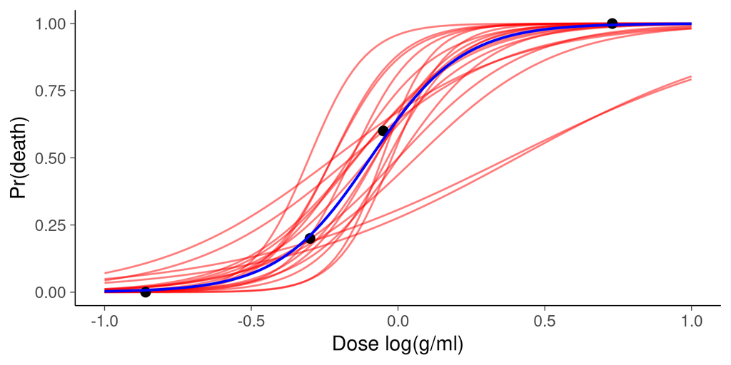

Figure 7

```r
bdraws1 |>
  resample_draws(ndraws = 20) |>
  expand_grid(x=seq(-1, 1, length = 100)) |>
  mutate(y = plogis(b_Intercept + b_dose * x)) |>
  ggplot() +
  geom_line(aes(x = x, y = y, group = .draw), alpha = .5, color = "red") +
  geom_point(data = df_bioassay, aes(x = dose, y = deaths / batch_size), size = 3) +
  geom_function(fun = \(x) plogis(mean(bdraws1$b_Intercept) + mean(bdraws1$b_dose)*x),
                color = "blue",
                linewidth = 1) +
  labs(x = "Dose log(g/ml)", y = "Pr(death)")
```

`brms` provides also shortcut for plotting the posterior mean and uncertainty. We use `plot=FALSE` and `[[1]]` to return a ggplot object, so that we can modify the axes labels.

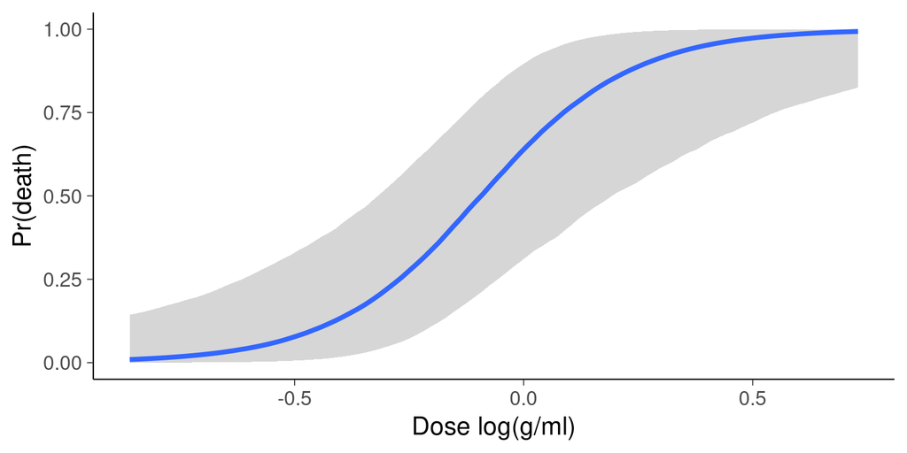

Figure 8

```r
p1 <- plot(conditional_effects(bfit1), plot=FALSE)[[1]] +
  labs(x = "Dose log(g/ml)", y = "Pr(death)")
p1
```

We can add data points with `ggplot::geom_point()`.

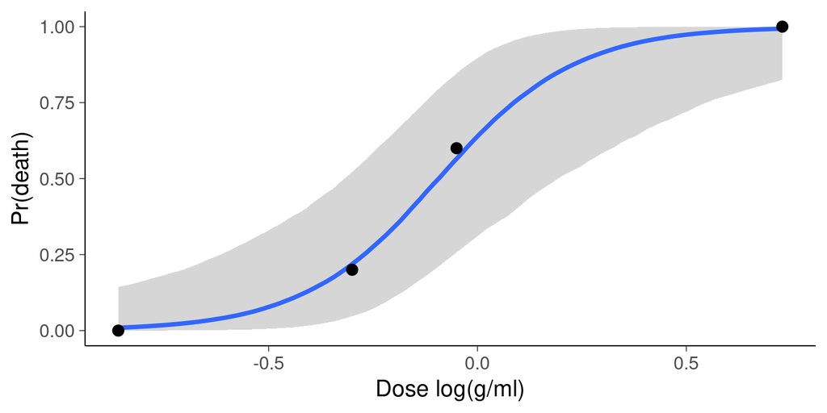

Figure 9

```r
p1 +
  geom_point(data = df_bioassay,
             inherit.aes = FALSE,
             aes(x = dose, y = deaths / batch_size),
             size = 3)
```

We can draw also individual posterior curves with `spaghetti=TRUE, ndraws=20`, but then the posterior mean would be computed only from 20 curves. Increasing `ndraws` would make the plotted posterior mean more accurate, but would make the spaghetti plot more messy.

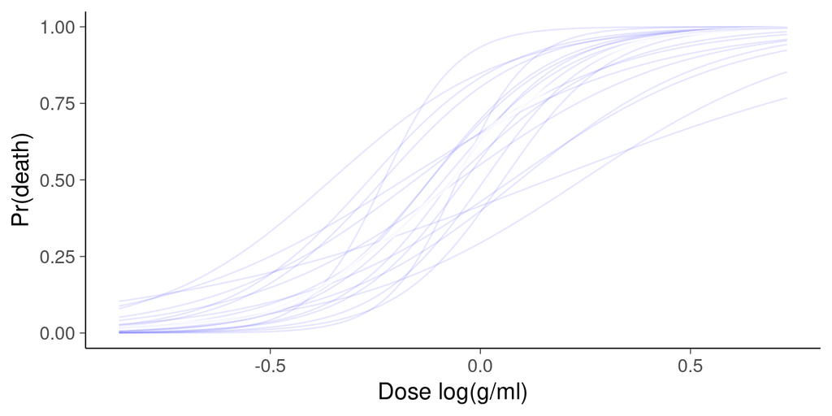

Figure 10

```r
p1 <- plot(conditional_effects(bfit1, spaghetti=TRUE, ndraws=20),
           plot=FALSE)[[1]] +
  labs(x = "Dose log(g/ml)", y = "Pr(death)")
p1
```

`marginaleffects` package also provides function for plotting the posterior prediction and uncertainty. By default it predicts on the scale of actual outcome, but as all batch sizes are equal we can transform to the interval from 0 to 1. We need to add the observed proportions of deaths with `geom_point()`.

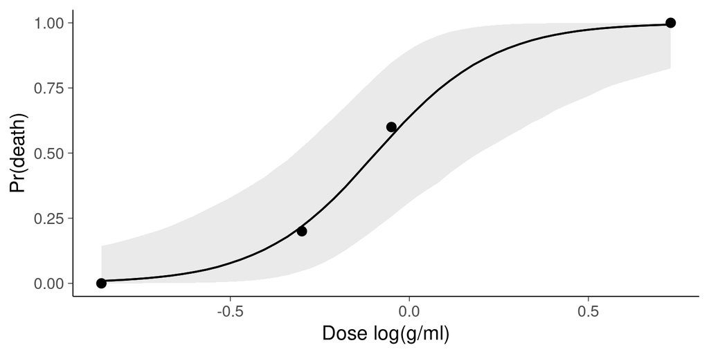

Figure 11

```r
p2 <- marginaleffects::plot_predictions(bfit1,
                                        condition = "dose",
                                        transform = \(x) x/5) +
  labs(x = "Dose log(g/ml)", y = "Pr(death)") +
  geom_point(data = df_bioassay,
             inherit.aes = FALSE,
             aes(x = dose, y = deaths / batch_size),
             size = 3)
p2
```

The `brms` and `marginaleffects` plotting functions demonstrate that often shortcut functions can provide quick plot or summary, but to have more control you may still need write more code to get what you really want.

# 7 LD50 posterior

Compute posterior draws for lethal dose 50 (LD50) in log(g/ml) and in mg/ml

```r
bdraws1 <- bdraws1 |>
  mutate_variables(LD50_log_g_ml = -b_Intercept/b_dose,
                   LD50_mg_ml = 1000 * exp(LD50_log_g_ml))
```

Posterior summary

```r
bdraws1 |>
  subset_draws(variable = "LD50_log_g_ml") |>
  summarize_draws()
```

```
# A tibble: 1 × 10
  variable         mean  median    sd   mad     q5   q95  rhat ess_bulk ess_tail
  <chr>           <dbl>   <dbl> <dbl> <dbl>  <dbl> <dbl> <dbl>    <dbl>    <dbl>
1 LD50_log_g_ml -0.0850 -0.0927 0.130 0.113 -0.278 0.132  1.00    2260.    2462.
```

Quantile dot plot of the LD50 (mg/ml) posterior.

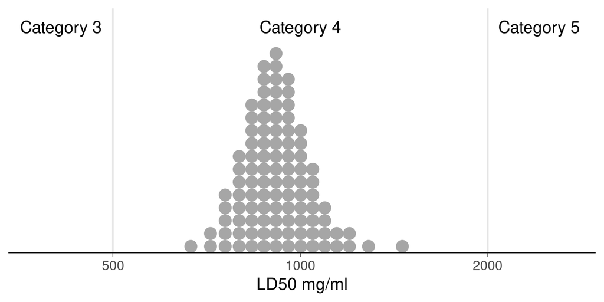

Figure 12

```r
ggplot_LD50_mg_ml +
  stat_dots(data = bdraws1, quantiles = 100) +
  coord_cartesian(expand = c(bottom = FALSE))
```

Kernel density plot of the LD50 (mg/ml) posterior.

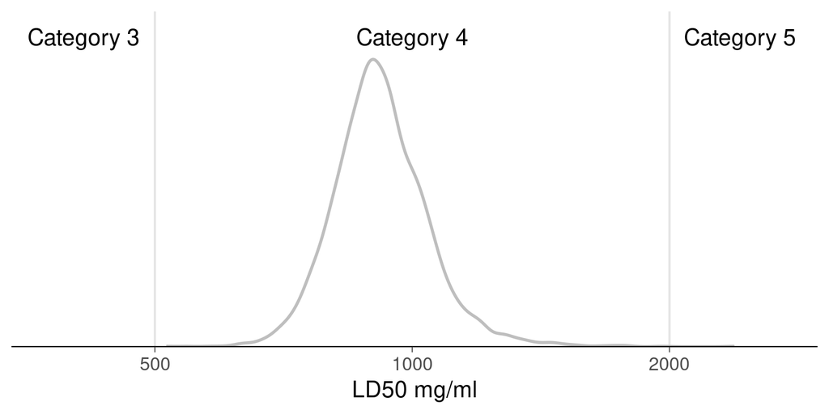

Figure 13

```r
ggplot_LD50_mg_ml +
  stat_slab(data = bdraws1, color = "gray", fill = NA) +
  coord_cartesian(expand = c(bottom = FALSE))
```

# References

Gelman, Andrew, John B Carlin, Hal S Stern, David B Dunson, Aki Vehtari, and Donald B Rubin. 2013. *Bayesian Data Analysis*. Third edition. CRC Press.

Racine-Poon, A., A. P. Grieve, H. Fluhler, and A. F. M. Smith. 1986. “Bayesian Methods in Practice: Experiences in the Pharmaceutical Industry (with Discussion).” *Applied Statistics* 35: 93–150.

# Licenses

- Code © 2025, Andrew Gelman and Aki Vehtari, licensed under BSD-3.
- Text © 2025, Andrew Gelman and Aki Vehtari, licensed under CC-BY-NC 4.0.